###### A good understanding of the macroeconomic cycle with alternating recession and expansion periods (also known as the business cycle) is important for various decision makers. Macroeconomic policy is often based on predictions of this cycle, and such predictions can influence investment decisions of large companies. Central banks and other institutions often publish so-called leading indicators that are helpful to predict the state of the economy. These indicators are based on macroeconomic series like job formation, interest rates, credit, demand, and supply. We will predict GDP growth by using quarterly data on a hypothetical economy from 1950 quarter 1 to 2015 quarter 4. The data set contains the GDP of the economy and two leading indicators li1 and li2.

###### The data file contains the following variables:

###### * DATE: Date of the observation;

###### * GDP: Gross Domestic Product of the economy;

###### * GDPIMPR: dummy variable indicating whether the GDP has increased (1) or decreased (0);

###### * LOGGDP: Log of Gross Domestic Product;

###### * GrowthRate: Relative growth of the economy: GrowthRatet = log(GDPt) − log(GDPt−1);

###### * li1: First leading indicator;

###### * li2: Second leading indicator;

###### * T: Linear trend (where the first observation, for 1950 quarter 1, is defined as 0)

###### In order to evaluate the predictive performance of econometric models, we need to split the data in two parts.As estimation sample we take the period from 1951 to 2010 (240 observations), and as evaluation sample we take the period from 2011 to 2015 (20 observations). The first year of data (1950) is used only to create lags of variables.

#### Library Used

```r
library(dplyr)
```

```r
library(ggplot2)
library(lmtest)
library(tidyr)
```

```r
library(readxl)
casestudy <- read_excel("C:/Users/USER/Downloads/casestudy.xls")
View(casestudy)
```

#### 1. To Analyze the effect of the leading indicators on GDPIMPR: Using Logit Model

###### Logistic regression analysis has also been used particularly to investigate the relationship between binary or ordinal response probability and explanatory variables and here, GDPIMPR is the binary variable.

###### Create new columns for indicator li1 and li2 with 1 quarter lag

```r
casestudy <- casestudy %>%
  mutate(newli1= lag(casestudy$li1),
         newli2= lag(casestudy$li2))
```

###### Ceating new columns for indicator li1 and li2 with 2 quarter lag

```r
casestudy <- casestudy %>%
  mutate(lag_b_li1= lag(casestudy$li1,2),
         lag_b_li2= lag(casestudy$li2,2))
```

###### Seperating the Date column into Year and Quarter

```r
casestudy <- casestudy %>%
  separate(Date, into =c("year","quarter"), sep=4)
```

###### Sort the data and use the data from 1951 to 2010 (Estimation Sample)

```r
datareq <- subset(casestudy, year>1950)
datareq1 <- subset(datareq, year<2011)
datareq1$GDPIMPR<-as.factor(datareq1$GDPIMPR)
datareq1$year<-as.numeric(datareq1$year)
```

###### To see whether we should include the leading indicator li1 and li2 in the model to explain the direction of economic development, we take four models where:

###### * Model 1: includes the constant,

###### * Model 2: includes newli1,

###### * Model 3: includes newli2,

###### * Model 4: includes both newli1 and newli2.

```r
model1 <- glm(data= datareq1, datareq1$GDPIMPR ~ 1 ,  family="binomial")
summary(model1)
```

```
##
## Call:
## glm(formula = datareq1$GDPIMPR ~ 1, family = "binomial", data = datareq1)
##
## Deviance Residuals:
##     Min       1Q   Median       3Q      Max
## -1.4823  -1.4823   0.9005   0.9005   0.9005
##
## Coefficients:
##             Estimate Std. Error z value Pr(>|z|)
## (Intercept)   0.6931     0.1369   5.062 4.15e-07 ***
## ---
## Signif. codes:  0 '***' 0.001 '**' 0.01 '*' 0.05 '.' 0.1 ' ' 1
##
## (Dispersion parameter for binomial family taken to be 1)
##
##     Null deviance: 305.53  on 239  degrees of freedom
## Residual deviance: 305.53  on 239  degrees of freedom
## AIC: 307.53
##
## Number of Fisher Scoring iterations: 4
```

```r
model2 <- glm(data= datareq1, datareq1$GDPIMPR~ datareq1$newli1 , family="binomial")
summary(model2)
```

```
##
## Call:
## glm(formula = datareq1$GDPIMPR ~ datareq1$newli1, family = "binomial",
##     data = datareq1)
##
## Deviance Residuals:
##     Min       1Q   Median       3Q      Max
## -2.1360  -1.0900   0.6368   0.8572   1.5710
##
## Coefficients:
##                 Estimate Std. Error z value Pr(>|z|)
## (Intercept)      0.81205    0.15085   5.383 7.32e-08 ***
## datareq1$newli1 -0.34038    0.07183  -4.739 2.15e-06 ***
## ---
## Signif. codes:  0 '***' 0.001 '**' 0.01 '*' 0.05 '.' 0.1 ' ' 1
##
## (Dispersion parameter for binomial family taken to be 1)
##
##     Null deviance: 305.53  on 239  degrees of freedom
## Residual deviance: 279.49  on 238  degrees of freedom
## AIC: 283.49
##
## Number of Fisher Scoring iterations: 3
```

```r
model3 <- glm(data= datareq1, datareq1$GDPIMPR ~ datareq1$newli2, family="binomial")
summary(model3)
```

```
##
## Call:
## glm(formula = datareq1$GDPIMPR ~ datareq1$newli2, family = "binomial",
##     data = datareq1)
##
## Deviance Residuals:
##     Min       1Q   Median       3Q      Max
## -1.9215  -1.3409   0.7684   0.9300   1.1645
##
## Coefficients:
##                 Estimate Std. Error z value Pr(>|z|)
## (Intercept)      0.63610    0.13946   4.561 5.08e-06 ***
## datareq1$newli2 -0.08651    0.03494  -2.476   0.0133 *
## ---
## Signif. codes:  0 '***' 0.001 '**' 0.01 '*' 0.05 '.' 0.1 ' ' 1
##
## (Dispersion parameter for binomial family taken to be 1)
##
##     Null deviance: 305.53  on 239  degrees of freedom
## Residual deviance: 299.04  on 238  degrees of freedom
## AIC: 303.04
##
## Number of Fisher Scoring iterations: 4
```

```r
model4 <- glm(data= datareq1, datareq1$GDPIMPR~ datareq1$newli1 + datareq1$newli2, family="binomial")
summary(model4)
```

```
##
## Call:
## glm(formula = datareq1$GDPIMPR ~ datareq1$newli1 + datareq1$newli2,
##     family = "binomial", data = datareq1)
##
## Deviance Residuals:
##     Min       1Q   Median       3Q      Max
## -2.1447  -1.0292   0.6054   0.8401   1.6253
##
## Coefficients:
##                 Estimate Std. Error z value Pr(>|z|)
## (Intercept)      0.72882    0.15358   4.745 2.08e-06 ***
## datareq1$newli1 -0.37186    0.07266  -5.118 3.09e-07 ***
## datareq1$newli2 -0.12029    0.03767  -3.194   0.0014 **
## ---
## Signif. codes:  0 '***' 0.001 '**' 0.01 '*' 0.05 '.' 0.1 ' ' 1
##
## (Dispersion parameter for binomial family taken to be 1)
##
##     Null deviance: 305.53  on 239  degrees of freedom
## Residual deviance: 268.36  on 237  degrees of freedom
## AIC: 274.36
##
## Number of Fisher Scoring iterations: 3
```

#### Likelihood Ratio Test

###### The likelihood ratio test (LRT) is a statistical test of the goodness-of-fit between two models. A relatively more complex model is compared to a simpler model to see if it fits a particular dataset significantly better.

###### Here we have four models and to see which one fits better the most we perform the Likelihood Ratio Test. So, let’s perform three Likelihood Ratio tests to prove both the individual and the joint significance of the 1-quarter lags of li1 and li2, where the alternative hypothesis is always the model with both indicators included.

```r
lmtest::lrtest(model1,model4)
```

```
## Likelihood ratio test
##
## Model 1: datareq1$GDPIMPR ~ 1
## Model 2: datareq1$GDPIMPR ~ datareq1$newli1 + datareq1$newli2
##   #Df  LogLik Df Chisq Pr(>Chisq)
## 1   1 -152.76
## 2   3 -134.18  2 37.17  8.483e-09 ***
## ---
## Signif. codes:  0 '***' 0.001 '**' 0.01 '*' 0.05 '.' 0.1 ' ' 1
```

```r
lmtest::lrtest(model2,model4)
```

```
## Likelihood ratio test
##
## Model 1: datareq1$GDPIMPR ~ datareq1$newli1
## Model 2: datareq1$GDPIMPR ~ datareq1$newli1 + datareq1$newli2
##   #Df  LogLik Df  Chisq Pr(>Chisq)
## 1   2 -139.75
## 2   3 -134.18  1 11.137  0.0008464 ***
## ---
## Signif. codes:  0 '***' 0.001 '**' 0.01 '*' 0.05 '.' 0.1 ' ' 1
```

```r
lmtest::lrtest(model3,model4)
```

```
## Likelihood ratio test
##
## Model 1: datareq1$GDPIMPR ~ datareq1$newli2
## Model 2: datareq1$GDPIMPR ~ datareq1$newli1 + datareq1$newli2
##   #Df  LogLik Df  Chisq Pr(>Chisq)
## 1   2 -149.52
## 2   3 -134.18  1 30.684  3.036e-08 ***
## ---
## Signif. codes:  0 '***' 0.001 '**' 0.01 '*' 0.05 '.' 0.1 ' ' 1
```

#### 2. Adding one more Lag

###### In time-series models, we must consider not only how much effect the two indicators has on GDPIMPR, but when it has the effect whether the effect is immediate or it emerges slowly. In order to answer these we must estimate the lag distribution relating GDPIMPR to the independent variable. Previously, we did take the independent variable with one lag but it can be the case that the leading indicators lead the economy by more than 1 quarter.

###### We inlcude the the independent variable li1 and li2 with both 1 quarter lag and 2 quarter lag. We have 4 models:

###### * Model 1: includes li1 and li2 with 1 quarter lag (model4)

###### * Model 2: includes li1 with 1 quarter lag and li2 with 2 quarter lag (model2.2)

###### * Model 3: includes li1 with 2 quarter lag and li2 with 1 quarter lag (model2.3)

###### * Model 4: includes li1 and li2 with 2 quarter lag (model2.4)

```r
model2.2 <- glm(data= datareq1, datareq1$GDPIMPR ~datareq1$newli1 + datareq1$lag_b_li2, family="binomial")
summary(model2.2)
```

```
##
## Call:
## glm(formula = datareq1$GDPIMPR ~ datareq1$newli1 + datareq1$lag_b_li2,
##     family = "binomial", data = datareq1)
##
## Deviance Residuals:
##     Min       1Q   Median       3Q      Max
## -2.1962  -1.0385   0.5790   0.8415   1.6120
##
## Coefficients:
##                    Estimate Std. Error z value Pr(>|z|)
## (Intercept)         0.73104    0.15355   4.761 1.93e-06 ***
## datareq1$newli1    -0.36650    0.07252  -5.054 4.34e-07 ***
## datareq1$lag_b_li2 -0.12070    0.03765  -3.206  0.00134 **
## ---
## Signif. codes:  0 '***' 0.001 '**' 0.01 '*' 0.05 '.' 0.1 ' ' 1
##
## (Dispersion parameter for binomial family taken to be 1)
##
##     Null deviance: 305.53  on 239  degrees of freedom
## Residual deviance: 268.25  on 237  degrees of freedom
## AIC: 274.25
##
## Number of Fisher Scoring iterations: 3
```

```r
model2.3 <- glm(data= datareq1, datareq1$GDPIMPR ~ datareq1$newli2 + datareq1$lag_b_li1, family="binomial")
summary(model2.3)
```

```
##
## Call:
## glm(formula = datareq1$GDPIMPR ~ datareq1$newli2 + datareq1$lag_b_li1,
##     family = "binomial", data = datareq1)
##
## Deviance Residuals:
##     Min       1Q   Median       3Q      Max
## -2.2798  -0.9581   0.5610   0.7588   1.7679
##
## Coefficients:
##                    Estimate Std. Error z value Pr(>|z|)
## (Intercept)         0.74569    0.15733   4.740 2.14e-06 ***
## datareq1$newli2    -0.13120    0.03859  -3.399 0.000675 ***
## datareq1$lag_b_li1 -0.42871    0.07632  -5.618 1.94e-08 ***
## ---
## Signif. codes:  0 '***' 0.001 '**' 0.01 '*' 0.05 '.' 0.1 ' ' 1
##
## (Dispersion parameter for binomial family taken to be 1)
##
##     Null deviance: 305.53  on 239  degrees of freedom
## Residual deviance: 260.69  on 237  degrees of freedom
## AIC: 266.69
##
## Number of Fisher Scoring iterations: 4
```

```r
model2.4 <- glm(data= datareq1, datareq1$GDPIMPR ~ datareq1$lag_b_li1 + datareq1$lag_b_li2, family="binomial")
summary(model2.4)
```

```
##
## Call:
## glm(formula = datareq1$GDPIMPR ~ datareq1$lag_b_li1 + datareq1$lag_b_li2,
##     family = "binomial", data = datareq1)
##
## Deviance Residuals:
##     Min       1Q   Median       3Q      Max
## -2.2163  -0.9685   0.5654   0.7807   1.7656
##
## Coefficients:
##                    Estimate Std. Error z value Pr(>|z|)
## (Intercept)         0.74877    0.15706   4.767 1.87e-06 ***
## datareq1$lag_b_li1 -0.42079    0.07599  -5.538 3.06e-08 ***
## datareq1$lag_b_li2 -0.12934    0.03837  -3.371 0.000749 ***
## ---
## Signif. codes:  0 '***' 0.001 '**' 0.01 '*' 0.05 '.' 0.1 ' ' 1
##
## (Dispersion parameter for binomial family taken to be 1)
##
##     Null deviance: 305.53  on 239  degrees of freedom
## Residual deviance: 260.92  on 237  degrees of freedom
## AIC: 266.92
##
## Number of Fisher Scoring iterations: 4
```

###### When analyzing data with a logistic regression, an equivalent statistic to R-squared does not exist. The model estimates from a logistic regression are maximum likelihood estimates. They are not calculated to minimize variance, so the OLS approach to goodness-of-fit does not apply. However, to evaluate the goodness-of-fit of logistic models, several pseudo R-squareds have been developed. So, we use Mcfadden R^2.

###### The Mcfadden R square compares the value of log likelihood function of two models both evaluated at maximum likelihood estimate (one is the model with only constant). The more it is close to 1 more appropriate is the model

```r
mcfadden2<- 1- logLik(model4)/logLik(model1)
mcfadden2
```

```
## 'log Lik.' 0.1216598 (df=3)
```

```r
mcfadden2<- 1- logLik(model2.2)/logLik(model1)
mcfadden2
```

```
## 'log Lik.' 0.1219991 (df=3)
```

```r
mcfadden2<- 1- logLik(model2.3)/logLik(model1)
mcfadden2
```

```
## 'log Lik.' 0.1467494 (df=3)
```

```r
mcfadden2<- 1- logLik(model2.4)/logLik(model1)
mcfadden2
```

```
## 'log Lik.' 0.1459928 (df=3)
```

###### If comparing two models on the same data, McFadden’s would be higher for the model with the greater likelihood. Therefore, model 2.3 is the most appropriate fit.

#### 3. Prediction Realization Table

###### When developing models for prediction, the most critical metric regards how well the model does in predicting the target variable.

###### Creating the Evaluation Sample

```r
datareq2<- subset(datareq, year>=2011)
datareq2$GDPIMPR<-as.numeric(datareq2$GDPIMPR)
```

```r
model2.3a <- glm(data= datareq2, datareq2$GDPIMPR ~ datareq2$newli2 + datareq2$lag_b_li1, family="binomial")
pp <- predict(model2.3a, newdata = datareq2)
matrix<- table(actual = datareq2$GDPIMPR, predicted= pp >0.5)
matrix
```

```
##       predicted
## actual FALSE TRUE
##      0     5    2
##      1     3   10
```

###### Hit rate is the probability that the actual and the predicted value matches. It is the sum of diagonal of predictive table by total of the table.

```r
hit_rate<- (matrix[[1,1]] + matrix[[2,2]])/sum(matrix)
hit_rate
```

```
## [1] 0.75
```

###### The total prediction ability is 75%.

### We use time series models to predict the size of the growth rate of the economy

#### 4. Augmented Dickey-Fuller test

###### Augmented Dickey Fuller test (ADF Test) is a common statistical test used to test whether a given Time series is stationary or not. It is one of the most commonly used statistical test when it comes to analyzing the stationary of a series. Stationary is very important factor on time series as model cannot forecast on non stationary time series data. The ADF test is a fundamentally a statistical significance test. There is a hypothesis testing involved with a null and alternate hypothesis and as a result a test statistic is computed and p-values get reported. From the statistic test and the p-values , we can make an inference as to whether a given time series is stationary or not.

```r
datareq1$GrowthRate<-as.numeric(datareq1$GrowthRate)
datareq1 <- datareq1 %>%
  mutate(LOGGDP_lag1 = lag(LOGGDP),
    GrowthRate_lag = lag(GrowthRate))
model4 <- lm(data = datareq1, GrowthRate ~ T + LOGGDP_lag1 + GrowthRate_lag )
summary(model4)
```

```
##
## Call:
## lm(formula = GrowthRate ~ T + LOGGDP_lag1 + GrowthRate_lag, data = datareq1)
##
## Residuals:
##        Min         1Q     Median         3Q        Max
## -0.0113539 -0.0024780 -0.0001732  0.0027260  0.0182799
##
## Coefficients:
##                  Estimate Std. Error t value Pr(>|t|)
## (Intercept)     9.334e-02  3.741e-02   2.495   0.0133 *
## T               6.380e-05  2.583e-05   2.470   0.0142 *
## LOGGDP_lag1    -2.000e-02  8.115e-03  -2.465   0.0144 *
## GrowthRate_lag  6.290e-01  5.092e-02  12.353   <2e-16 ***
## ---
## Signif. codes:  0 '***' 0.001 '**' 0.01 '*' 0.05 '.' 0.1 ' ' 1
##
## Residual standard error: 0.004552 on 235 degrees of freedom
##   (1 observation deleted due to missingness)
## Multiple R-squared:  0.3969, Adjusted R-squared:  0.3892
## F-statistic: 51.54 on 3 and 235 DF,  p-value: < 2.2e-16
```

###### The t value of LOGGDP_lag1 is -2.4 > -3.5 so we are not able to reject Ho of null hypothesis of non stationarity. Therefore, LOGGDP is not stationary.

###### In the previous step we saw that LOGGDP is not stationary so to convert it into a stationary one, we take the first order difference of GrowthRate.

```r
datareq1 <- datareq1 %>%
  mutate(GrowthRate_lag = lag(GrowthRate),
         changeinGrowthRate = GrowthRate- GrowthRate_lag)
modelp <- lm(data = datareq1, changeinGrowthRate ~ T + GrowthRate_lag )
summary(modelp)
```

```
##
## Call:
## lm(formula = changeinGrowthRate ~ T + GrowthRate_lag, data = datareq1)
##
## Residuals:
##        Min         1Q     Median         3Q        Max
## -0.0105049 -0.0027129 -0.0005899  0.0027225  0.0184477
##
## Coefficients:
##                  Estimate Std. Error t value Pr(>|t|)
## (Intercept)     1.153e-03  6.322e-04   1.823   0.0695 .
## T               1.024e-06  4.315e-06   0.237   0.8126
## GrowthRate_lag -3.831e-01  5.122e-02  -7.478 1.47e-12 ***
## ---
## Signif. codes:  0 '***' 0.001 '**' 0.01 '*' 0.05 '.' 0.1 ' ' 1
##
## Residual standard error: 0.0046 on 236 degrees of freedom
##   (1 observation deleted due to missingness)
## Multiple R-squared:  0.1916, Adjusted R-squared:  0.1847
## F-statistic: 27.96 on 2 and 236 DF,  p-value: 1.263e-11
```

#### 5.Estimating the GrowthRate Model

###### We include a constant, a lag term and lag terms of indicators li1 and li2 (we include different lags of the indicators li1 and li2). Finally we will use R^2 to choose the most appropriate one.

```r
datareq1 <- datareq1 %>%
  mutate(GrowthRate_lag= lag(GrowthRate))
datareq1$GrowthRate_lag<-as.numeric(datareq1$GrowthRate_lag)
model5 <- lm(data = datareq1, GrowthRate ~ GrowthRate_lag + newli1 + newli2)
summary(model5)
```

```
##
## Call:
## lm(formula = GrowthRate ~ GrowthRate_lag + newli1 + newli2, data = datareq1)
##
## Residuals:
##        Min         1Q     Median         3Q        Max
## -0.0097677 -0.0028551 -0.0002089  0.0026353  0.0158221
##
## Coefficients:
##                  Estimate Std. Error t value Pr(>|t|)
## (Intercept)     1.738e-03  3.213e-04   5.409 1.56e-07 ***
## GrowthRate_lag  4.611e-01  5.008e-02   9.206  < 2e-16 ***
## newli1         -1.024e-03  1.331e-04  -7.693 3.94e-13 ***
## newli2         -1.496e-04  6.456e-05  -2.317   0.0214 *
## ---
## Signif. codes:  0 '***' 0.001 '**' 0.01 '*' 0.05 '.' 0.1 ' ' 1
##
## Residual standard error: 0.004115 on 235 degrees of freedom
##   (1 observation deleted due to missingness)
## Multiple R-squared:  0.5071, Adjusted R-squared:  0.5008
## F-statistic: 80.59 on 3 and 235 DF,  p-value: < 2.2e-16
```

```r
model5a <- lm(data = datareq1, GrowthRate ~ GrowthRate_lag + newli1 + lag_b_li2)
summary(model5a)
```

```
##
## Call:
## lm(formula = GrowthRate ~ GrowthRate_lag + newli1 + lag_b_li2,
##     data = datareq1)
##
## Residuals:
##        Min         1Q     Median         3Q        Max
## -0.0097860 -0.0028047 -0.0002279  0.0025338  0.0159151
##
## Coefficients:
##                  Estimate Std. Error t value Pr(>|t|)
## (Intercept)     1.754e-03  3.205e-04   5.474 1.13e-07 ***
## GrowthRate_lag  4.576e-01  5.024e-02   9.108  < 2e-16 ***
## newli1         -1.019e-03  1.328e-04  -7.671 4.52e-13 ***
## lag_b_li2      -1.472e-04  6.446e-05  -2.283   0.0233 *
## ---
## Signif. codes:  0 '***' 0.001 '**' 0.01 '*' 0.05 '.' 0.1 ' ' 1
##
## Residual standard error: 0.004116 on 235 degrees of freedom
##   (1 observation deleted due to missingness)
## Multiple R-squared:  0.5068, Adjusted R-squared:  0.5005
## F-statistic: 80.49 on 3 and 235 DF,  p-value: < 2.2e-16
```

```r
model5b <- lm(data = datareq1, GrowthRate ~ GrowthRate_lag +lag_b_li1+ newli2)
summary(model5b)
```

```
##
## Call:
## lm(formula = GrowthRate ~ GrowthRate_lag + lag_b_li1 + newli2,
##     data = datareq1)
##
## Residuals:
##        Min         1Q     Median         3Q        Max
## -0.0090510 -0.0026853 -0.0002403  0.0023648  0.0164926
##
## Coefficients:
##                  Estimate Std. Error t value Pr(>|t|)
## (Intercept)     0.0018940  0.0003401   5.569 6.98e-08 ***
## GrowthRate_lag  0.4110614  0.0569338   7.220 7.16e-12 ***
## lag_b_li1      -0.0009867  0.0001525  -6.470 5.65e-10 ***
## newli2         -0.0001584  0.0000672  -2.357   0.0193 *
## ---
## Signif. codes:  0 '***' 0.001 '**' 0.01 '*' 0.05 '.' 0.1 ' ' 1
##
## Residual standard error: 0.004241 on 235 degrees of freedom
##   (1 observation deleted due to missingness)
## Multiple R-squared:  0.4763, Adjusted R-squared:  0.4696
## F-statistic: 71.24 on 3 and 235 DF,  p-value: < 2.2e-16
```

```r
model5c <- lm(data = datareq1, GrowthRate ~ GrowthRate_lag +lag_b_li1 + lag_b_li2)
summary(model5c)
```

```
##
## Call:
## lm(formula = GrowthRate ~ GrowthRate_lag + lag_b_li1 + lag_b_li2,
##     data = datareq1)
##
## Residuals:
##       Min        1Q    Median        3Q       Max
## -0.009127 -0.002618 -0.000285  0.002404  0.016152
##
## Coefficients:
##                  Estimate Std. Error t value Pr(>|t|)
## (Intercept)     1.910e-03  3.395e-04   5.625 5.25e-08 ***
## GrowthRate_lag  4.075e-01  5.716e-02   7.130 1.23e-11 ***
## lag_b_li1      -9.819e-04  1.521e-04  -6.456 6.09e-10 ***
## lag_b_li2      -1.577e-04  6.706e-05  -2.351   0.0196 *
## ---
## Signif. codes:  0 '***' 0.001 '**' 0.01 '*' 0.05 '.' 0.1 ' ' 1
##
## Residual standard error: 0.004242 on 235 degrees of freedom
##   (1 observation deleted due to missingness)
## Multiple R-squared:  0.4762, Adjusted R-squared:  0.4695
## F-statistic: 71.22 on 3 and 235 DF,  p-value: < 2.2e-16
```

###### The coefficient of determination (R² or r-squared) is a statistical measure in a regression model that determines the proportion of variance in the dependent variable that can be explained by the independent variable. In other words, the coefficient of determination tells one how well the data fits the model (the goodness of fit).

###### We see the first model (one which includes 1 quarter lag of li1 and li2) has the highest R^2 and therefore, is the best fit.

#### 6. Testing for serial correlation

###### In the classical linear regression model we assume that successive values of the disturbance term are temporarily independent when observations are taken over time. But when this assumption is violated then the problem is known as Autocorrelation. When the disturbance term exhibits serial correlation, the value of the standard error of the parameter estimates are affected and the predictions based on ordinary least square estimates will be inefficient. So we cannot estimate the correct values of the parameters and the estimates are biased.

###### We use Breusch-Godfrey test. This test is used to check autocorrelation of errors in a regression model. It makes use of the residuals from the model being considered in a regression analysis, and a test statistic is derived from these.

```r
datareq1$GrowthRate<-as.numeric(datareq1$GrowthRate)
bgtest(formula =GrowthRate ~ GrowthRate_lag + newli1 + newli2 , order=1, data =datareq1)
```

```
##
##  Breusch-Godfrey test for serial correlation of order up to 1
##
## data:  GrowthRate ~ GrowthRate_lag + newli1 + newli2
## LM test = 0.2367, df = 1, p-value = 0.6266
```

###### The p value >0.05 therefore we are not able to reject the null hypothesis of no serial correlation.

#### 7. Predicting Growth Rates

###### Using the model 5 to generate a set of twenty one-step-ahead predictions for the growth rates in each quarter of the period 2011 to 2015 i.e, the evaluation sample.

```r
datareq2 <- datareq2 %>%
  mutate(GrowthRate_lag= lag(GrowthRate))
datareq2$GrowthRate_lag<-as.numeric(datareq2$GrowthRate_lag)
datareq2$GrowthRate<-as.numeric(datareq2$GrowthRate)
prediction <- predict(model5, newdata = datareq2)
```

###### Root Mean Square Error (RMSE) is a standard way to measure the error of a model in predicting quantitative data. Root mean squared error (RMSE) is the square root of the mean of the square of all of the error. RMSE is a good measure of accuracy, but only to compare prediction errors of different models or model configurations for a particular variable and not between variables, as it is scale-dependent.

```r
rmse <- function(actual, predicted){
  sqrt(mean((actual - predicted)^2, na.rm = TRUE))
}
rmse <- rmse(actual = datareq2$GrowthRate, predicted = prediction)
rmse
```

```
## [1] 0.003136932
```

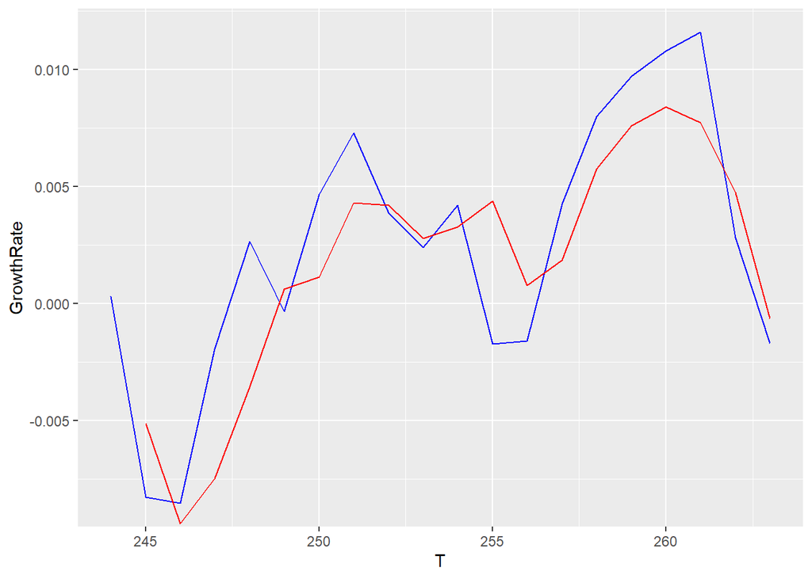

```r
datareq2 %>%
  ggplot(aes(x= T, y= GrowthRate ))  +
  geom_line(color= "blue") +
  geom_line(y= prediction , color= "red")
```

###### Lower RMSE indicates a better fit. Both the RSME, as well as the previous figures, show that the prediction capacity of the model is quite good to forecast the “Growth Rates”.